# ch6-ex-applied

S Zimine

12/4/2017

# Ex 8 (Applied )

### a)

```r
set.seed(1)
n<-100
x<-rnorm(n)
epsilon <-rnorm(n)
```

### b)

```r
beta0<- 3
beta1<- 2
beta2<- -3
beta3<- 0.3

y<-beta0 + beta1*x + beta2*x^2 + beta3*x^3 + epsilon
head(y)
```

```
## [1] -0.12436191  3.31008591 -1.85205402 -0.06821313  2.68943771  0.94115138
```

### c)

```r
require(leaps)
dataset <- data.frame(y,x,x^2,x^3,x^4,x^5,x^6,x^7,x^8,x^9,x^10)
colnames(dataset) <- c("response", "x1", "x2", "x3", "x4", "x5"
                      ,"x6", "x7", "x8", "x9", "x10")
p_feats<-dim(dataset)[2] -1  ## on all 10 features.
regfit.full<-regsubsets(response~., data=dataset, nvmax=p_feats)
reg.summary<-summary(regfit.full)
print(reg.summary)
```

```
## Subset selection object
## Call: regsubsets.formula(response ~ ., data = dataset, nvmax = p_feats)
## 10 Variables  (and intercept)
##     Forced in Forced out
## x1      FALSE      FALSE
## x2      FALSE      FALSE
## x3      FALSE      FALSE
## x4      FALSE      FALSE
## x5      FALSE      FALSE
## x6      FALSE      FALSE
## x7      FALSE      FALSE
## x8      FALSE      FALSE
## x9      FALSE      FALSE
## x10     FALSE      FALSE
## 1 subsets of each size up to 10
## Selection Algorithm: exhaustive
##           x1  x2  x3  x4  x5  x6  x7  x8  x9  x10
## 1  ( 1 )  " " "*" " " " " " " " " " " " " " " " "
## 2  ( 1 )  "*" "*" " " " " " " " " " " " " " " " "
## 3  ( 1 )  "*" "*" " " " " " " " " "*" " " " " " "
## 4  ( 1 )  "*" "*" " " " " "*" "*" " " " " " " " "
## 5  ( 1 )  "*" "*" " " " " " " " " "*" "*" "*" " "
## 6  ( 1 )  "*" "*" " " " " " " "*" "*" "*" " " "*"
## 7  ( 1 )  "*" "*" " " "*" " " "*" "*" "*" " " "*"
## 8  ( 1 )  "*" "*" " " "*" "*" "*" " " "*" "*" "*"
## 9  ( 1 )  "*" "*" " " "*" "*" "*" "*" "*" "*" "*"
## 10  ( 1 ) "*" "*" "*" "*" "*" "*" "*" "*" "*" "*"
```

Lets define a function to plot Cp, BIC and ajusted R squared

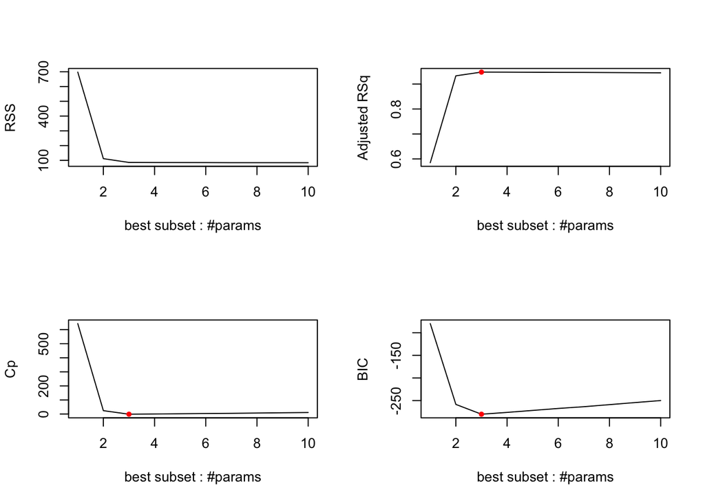

```r
plot_regularization_measures<-function(model, label="best subset") {
    model.summary <- summary(model)
    xlbl <- paste(label, ": #params")
    par(mfrow=c(2,2))
    plot(model.summary$rss ,xlab=xlbl,ylab="RSS",type="l")
    #adjusted r squared
    plot(model.summary$adjr2, xlab=xlbl,ylab="Adjusted RSq", type="l")
    idx1<-which.max(model.summary$adjr2)
    points(idx1, model.summary$adjr2[idx1],col="red", cex=1, pch=20)
    #CP
    plot(model.summary$cp, xlab=xlbl,ylab="Cp", type="l")
    idx2<-which.min(model.summary$cp)
    points(idx2, model.summary$cp[idx2],col="red", cex=1, pch=20)
    #BIC
    plot(model.summary$bic, xlab=xlbl,ylab="BIC", type="l")
    idx3<-which.min(model.summary$bic)
    points(idx3, model.summary$bic[idx3],col="red", cex=1, pch=20)
    par(mfrow=c(1,1))
}
### lets plot this measures for best subset selection
plot_regularization_measures(model=regfit.full)
```

We observet that all Cp, BIC and $R^2_{adj}$ show that the best model has 3 parameters. Lets plot its coefficients to see if they match the true model betas.

```r
print(coefficients(regfit.full , id=3))
```

```
## (Intercept)          x1          x2          x7
##  3.07627412  2.35623596 -3.16514887  0.01046843
```

The alternative way to define the model is by using `poly()` function (Asad solution)

```r
dataset_same = data.frame("y" = y, "x" = x)
regfit.full_b = regsubsets(y~poly(x, 10, raw=T), data=dataset_same, nvmax=p_feats)
model.summary <- summary(regfit.full_b)
#which model is best
print(paste( "min cp: ",which.min(model.summary$cp)
            ,"min bic: ",which.min(model.summary$bic)
            , "max adj r^2:",which.max(model.summary$adjr2)))
```

```
## [1] "min cp:  3 min bic:  3 max adj r^2: 3"
```

### d)

##### Forward step selection

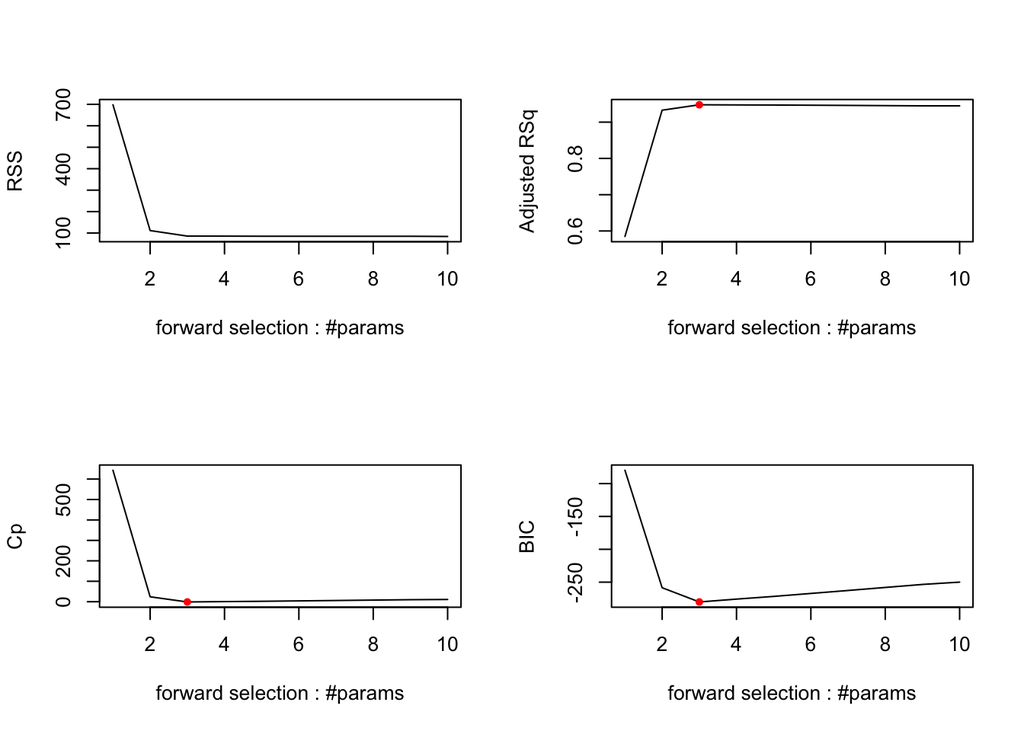

```r
regfit.fwd<-regsubsets(response~., data=dataset, nvmax=p_feats, method="forward")
reg.summary<-summary(regfit.fwd)

plot_regularization_measures(model=regfit.fwd, label="forward selection")
```

We obtain the best model for the same number of params: 3. Coefficients are identical to those of best subset selection model.

```r
print(coefficients(regfit.fwd , id=3))
```

```
## (Intercept)          x1          x2          x7
##  3.07627412  2.35623596 -3.16514887  0.01046843
```

##### Backward step selection

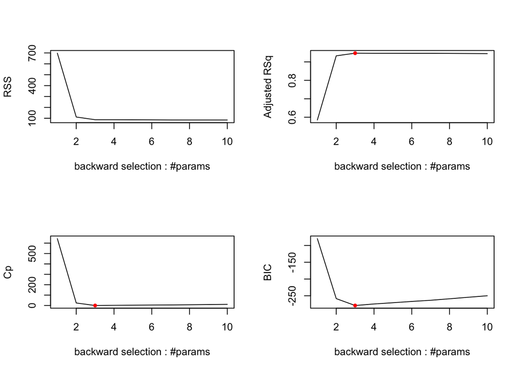

```r
regfit.bwd<-regsubsets(response~., data=dataset, nvmax=p_feats, method="backward")
reg.summary<-summary(regfit.bwd)

plot_regularization_measures(model=regfit.bwd, label="backward selection")
```

```r
print(coefficients(regfit.bwd , id=3))
```

```
##  (Intercept)           x1           x2           x9
##  3.078881355  2.419817953 -3.177235617  0.001870457
```

For backward and forward selection results are identical as for best subset selection. Coefficients are close to those obtained by forward selection model.

### e)

##### LASSO

```r
require(glmnet)
xv <- model.matrix(response~., data=dataset)[,-1]
yv <- dataset$response
set.seed(1)
grid <- 10^seq(10,-2,length=100)

## cross validation to select optimal lambda
cv.out <- cv.glmnet(xv, yv, alpha=1 ) #alpha=1 - lasso
bestlambda <- cv.out$lambda.min
print(paste("lasso cv best lambda:",bestlambda))
```

```
## [1] "lasso cv best lambda: 0.0208112737824086"
```

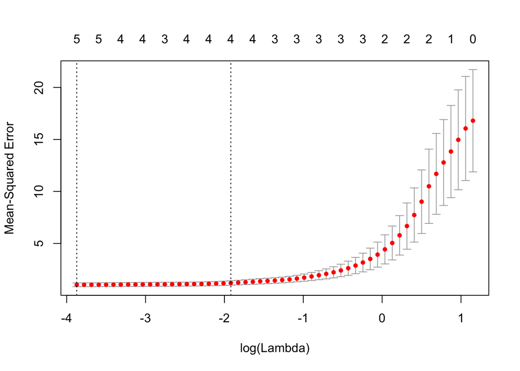

```r
plot(cv.out)
```

```r
##fit lasso model on all data
lasso.mod <- glmnet(xv,yv, alpha=1, lambda=grid, thresh=1e-12)
lasso.pred <- predict(lasso.mod, s=bestlambda, type="coefficients")
print(lasso.pred)
```

```
## 11 x 1 sparse Matrix of class "dgCMatrix"
##                         1
## (Intercept)  3.061665e+00
## x1           2.268948e+00
## x2          -3.140676e+00
## x3           .
## x4           .
## x5           3.882688e-02
## x6           .
## x7           2.942883e-03
## x8           .
## x9           .
## x10          2.938634e-05
```

We observe that coefficents x0, x1 and x2 match closely the betas of the real Y function“.

The alternative way to define the lasso model is by using `poly()` function (Asad solution)

```r
xmat = model.matrix(y~poly(x, 10, raw=T), data=dataset_same)[, -1]
mod.lasso = cv.glmnet(xmat, y, alpha=1)
best.lambda = mod.lasso$lambda.min
best.lambda
```

```
## [1] 0.03991416
```

```r
lasso.model = glmnet(xmat, y, alpha=1)
best.pred <- predict(lasso.model, s=best.lambda, type="coefficients")
print(best.pred)
```

```
## 11 x 1 sparse Matrix of class "dgCMatrix"
##                                    1
## (Intercept)             3.0398151056
## poly(x, 10, raw = T)1   2.2303371338
## poly(x, 10, raw = T)2  -3.1033192679
## poly(x, 10, raw = T)3   .
## poly(x, 10, raw = T)4   .
## poly(x, 10, raw = T)5   0.0498410763
## poly(x, 10, raw = T)6   .
## poly(x, 10, raw = T)7   0.0008068431
## poly(x, 10, raw = T)8   .
## poly(x, 10, raw = T)9   .
## poly(x, 10, raw = T)10  .
```

As we see this approach computes coefficients which are slightly better.

### f)

**Best Subset selection**

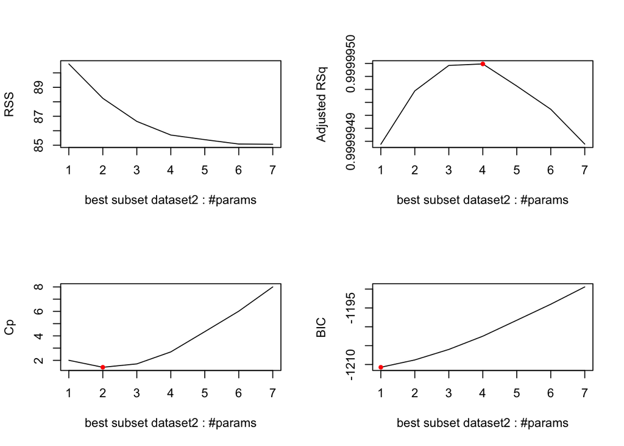

```r
beta7 <- 7
y <- beta0 + beta7 * x^7 + epsilon
dataset2 <- data.frame("y" = y, "x" = x)
regfit.full<-regsubsets(y~poly(x,7,raw=TRUE), data=dataset2, nvmax=7)

plot_regularization_measures(model=regfit.full, label="best subset dataset2")
```

```r
print(coefficients(regfit.full, id=1))
```

```
##             (Intercept) poly(x, 7, raw = TRUE)7
##                 2.95894                 7.00077
```

```r
print(coefficients(regfit.full, id=2))
```

```
##             (Intercept) poly(x, 7, raw = TRUE)2 poly(x, 7, raw = TRUE)7
##               3.0704904              -0.1417084               7.0015552
```

```r
print(coefficients(regfit.full, id=4))
```

```
##             (Intercept) poly(x, 7, raw = TRUE)1 poly(x, 7, raw = TRUE)2
##               3.0762524               0.2914016              -0.1617671
## poly(x, 7, raw = TRUE)3 poly(x, 7, raw = TRUE)7
##              -0.2526527               7.0091338
```

We observe that model with 1 predictor picked by BIC is the most accurate.

**Lasso**

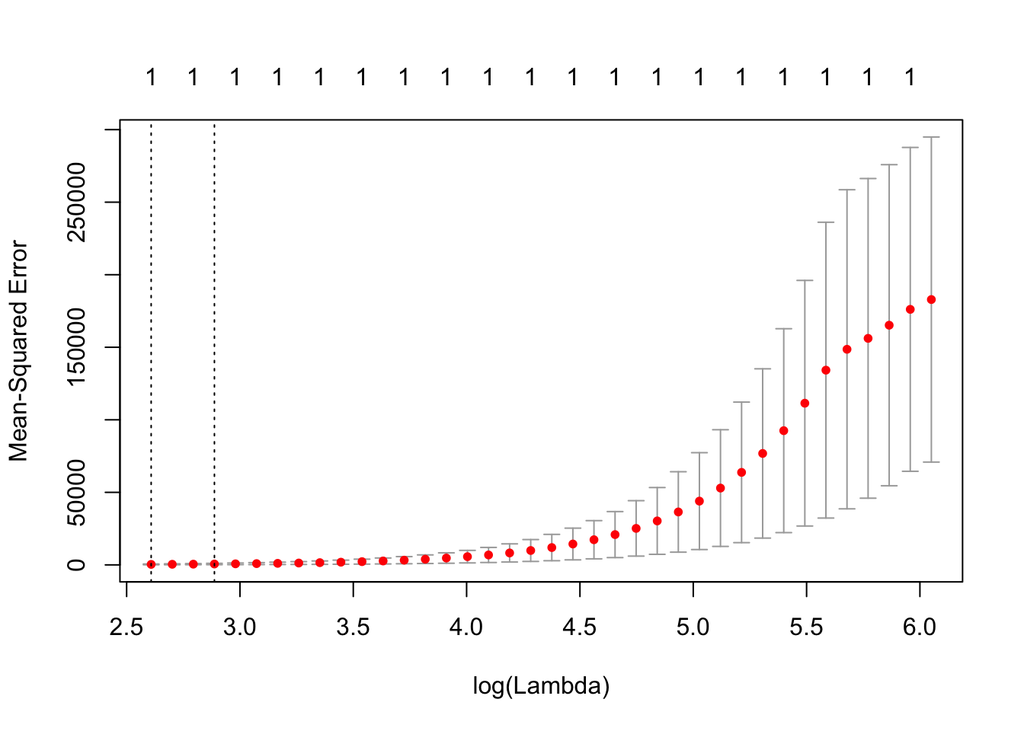

```r
xmat = model.matrix(y~poly(x, 7, raw=T), data=dataset2)[, -1]
cv.lasso <- cv.glmnet(xmat, y, alpha=1)
plot(cv.lasso)
```

```r
bestlambda <- cv.lasso$lambda.min
print(paste("best lambda:", bestlambda))
```

```
## [1] "best lambda: 13.5747838622354"
```

```r
lasso.mod <- glmnet(xmat, y, alpha=1, lambda=grid, thresh=1e-12)
lasso.pred <- predict(lasso.mod, s=bestlambda, type="coefficients")
print(lasso.pred)
```

```
## 8 x 1 sparse Matrix of class "dgCMatrix"
##                             1
## (Intercept)          3.904188
## poly(x, 7, raw = T)1 .
## poly(x, 7, raw = T)2 .
## poly(x, 7, raw = T)3 .
## poly(x, 7, raw = T)4 .
## poly(x, 7, raw = T)5 .
## poly(x, 7, raw = T)6 .
## poly(x, 7, raw = T)7 6.776797
```

We observe that lasso’s coefficients are close the betas of real model, interecept is quite off from 3.0.

# Ex 9 (Applied )

```r
rm(list=ls()) #clean all variables
```

### a)

```r
require(ISLR)
data(College)
dim(College)
```

```
## [1] 777  18
```

Split the dataset into train and test half - half.

```r
set.seed(11)
full_idx <- 1:nrow(College)
train <- sample(full_idx, length(full_idx)/2 )
test <- full_idx[-train]
```

### b)

##### Linear model (OLS)

```r
lm.mod <- lm(Apps~., data=College, subset=train)
summary(lm.mod)
```

```
##
## Call:
## lm(formula = Apps ~ ., data = College, subset = train)
##
## Residuals:
##     Min      1Q  Median      3Q     Max
## -3046.3  -435.3   -60.5   312.4  6494.1
##
## Coefficients:
##               Estimate Std. Error t value Pr(>|t|)
## (Intercept) -629.18373  540.83636  -1.163  0.24544
## PrivateYes  -339.64363  186.49954  -1.821  0.06939 .
## Accept         1.30641    0.07343  17.790  < 2e-16 ***
## Enroll        -0.70342    0.28304  -2.485  0.01339 *
## Top10perc     38.52655    8.56038   4.501 9.09e-06 ***
## Top25perc    -10.82041    6.68617  -1.618  0.10644
## F.Undergrad    0.14708    0.05019   2.930  0.00359 **
## P.Undergrad    0.02622    0.05363   0.489  0.62516
## Outstate      -0.07353    0.02819  -2.608  0.00948 **
## Room.Board     0.03461    0.06809   0.508  0.61155
## Books         -0.23172    0.29607  -0.783  0.43434
## Personal       0.01646    0.09160   0.180  0.85747
## PhD           -3.83617    6.25554  -0.613  0.54009
## Terminal      -6.12731    6.80595  -0.900  0.36855
## S.F.Ratio     15.90832   17.39257   0.915  0.36096
## perc.alumni   -8.83460    5.84260  -1.512  0.13136
## Expend         0.16340    0.02323   7.034 9.79e-12 ***
## Grad.Rate      9.95699    4.20521   2.368  0.01841 *
## ---
## Signif. codes:  0 '***' 0.001 '**' 0.01 '*' 0.05 '.' 0.1 ' ' 1
##
## Residual standard error: 994 on 370 degrees of freedom
## Multiple R-squared:  0.9318, Adjusted R-squared:  0.9286
## F-statistic: 297.1 on 17 and 370 DF,  p-value: < 2.2e-16
```

```r
y<-College$Apps
lm.pred <- predict(lm.mod, College[test,])
mse_lm <- mean( (y[test] -lm.pred)^2 )
paste("test MSE linear model: ",mse_lm)
```

```
## [1] "test MSE linear model:  1538442.23117977"
```

### c)

##### Ridge

```r
full.mat <- model.matrix(Apps~., data=College)
train.mat <- model.matrix(Apps~., data=College[train,])
test.mat <- model.matrix(Apps~., data=College[test,])
y.train <- y[train]
y.test <- y[test]

grid <- 10^seq(10,-2,length=100)

ridge.cv <- cv.glmnet(train.mat, y.train, alpha=0, lambda=grid, thresh=1e-12)
bestlam <- ridge.cv$lambda.min
paste("cv Ridge best lambda:",bestlam)
```

```
## [1] "cv Ridge best lambda: 18.7381742286039"
```

```r
ridge.pred <- predict(ridge.cv, s=bestlam, newx=test.mat)
mse_ridge_best <- mean((ridge.pred-y.test)^2)
print(paste("test MSE  ridge model: ",mse_ridge_best))
```

```
## [1] "test MSE  ridge model:  1608845.96969968"
```

### d)

Lasso

```r
lasso.cv <- cv.glmnet(train.mat, y.train, alpha=1 , lambda=grid, thresh=1e-12) #lasso on train
bestlam <- lasso.cv$lambda.min
print(paste("cv Lasso best lambda:",bestlam))
```

```
## [1] "cv Lasso best lambda: 18.7381742286039"
```

```r
lasso.pred <- predict(lasso.cv, s=bestlam, newx=test.mat)
mse_lasso_best <- mean((lasso.pred-y.test)^2)
print(paste("test MSE  lasso model: ",mse_lasso_best))
```

```
## [1] "test MSE  lasso model:  1632226.02464396"
```

```r
lasso.mod <- glmnet(full.mat, y, alpha=1) #on full data
lasso.coefs <-predict(lasso.mod,s=bestlam, type="coefficients")
print(lasso.coefs)
```

```
## 19 x 1 sparse Matrix of class "dgCMatrix"
##                         1
## (Intercept) -5.813707e+02
## (Intercept)  .
## PrivateYes  -4.368911e+02
## Accept       1.471991e+00
## Enroll      -2.541925e-01
## Top10perc    3.574808e+01
## Top25perc   -3.838790e+00
## F.Undergrad  .
## P.Undergrad  2.596168e-02
## Outstate    -6.179537e-02
## Room.Board   1.284644e-01
## Books        .
## Personal     2.520096e-03
## PhD         -6.025350e+00
## Terminal    -3.256552e+00
## S.F.Ratio    6.026031e+00
## perc.alumni -8.955597e-01
## Expend       7.076914e-02
## Grad.Rate    5.580536e+00
```

### e)

##### PCR

```r
library(pls)
```

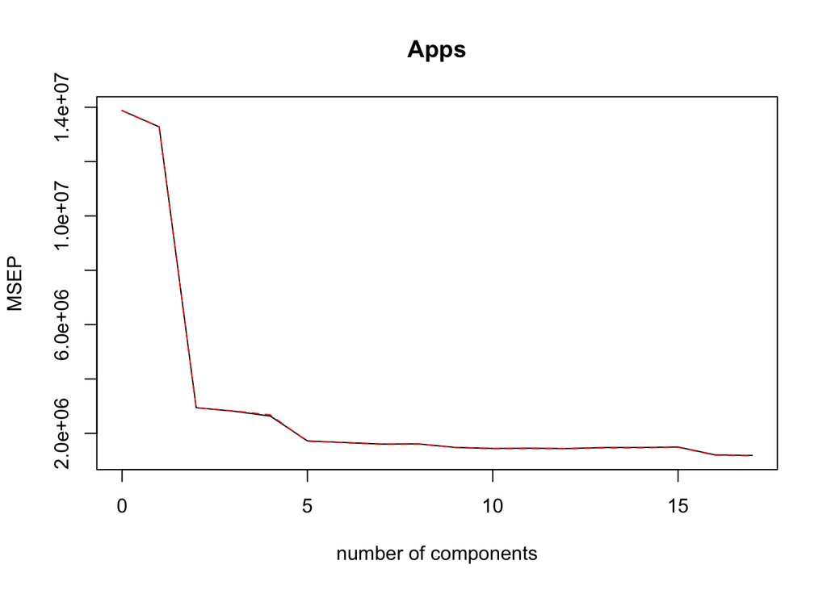

```r
pcr.fit <- pcr(Apps~. ,data=College,subset=train,scale=TRUE, validation="CV")
validationplot(pcr.fit, val.type="MSEP")
```

```r
pcr.pred <- predict(pcr.fit, College[test,], ncomp=10)
mse_pcr <- mean( (pcr.pred - y.test)^2 )
print(paste("test MSE  PCR ncomp=10: ",mse_pcr))
```

```
## [1] "test MSE  PCR ncomp=10:  3014496.46451856"
```

### f)

##### PLS

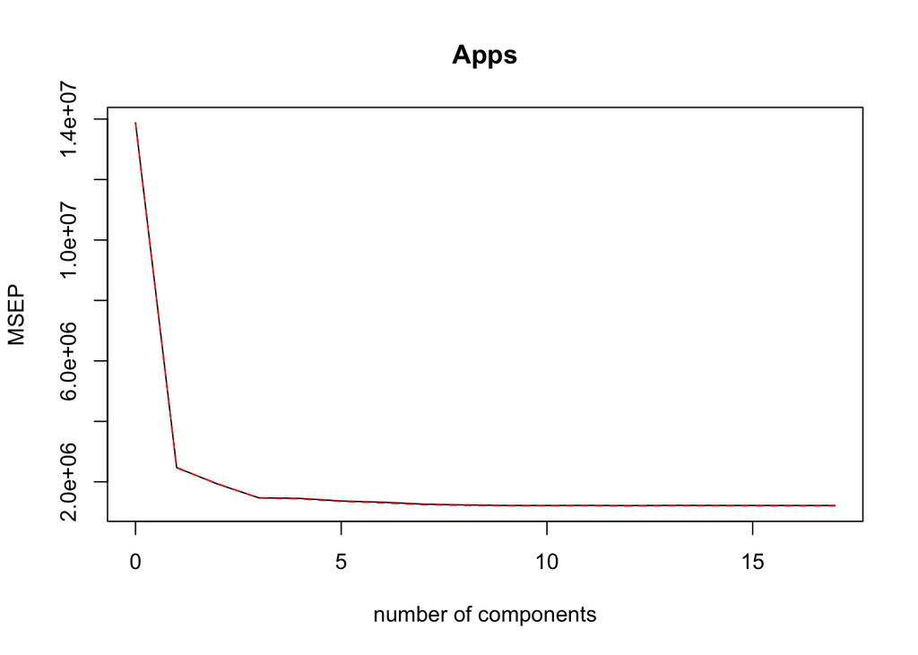

```r
pls.fit <- plsr(Apps~. ,data=College,subset=train
               ,scale=TRUE, validation="CV")
validationplot(pls.fit, val.type="MSEP")
```

```r
pls.pred <- predict(pls.fit, College[test,], ncomp=10)
mse_pls <- mean( (pls.pred - y.test)^2 )
print(paste("test MSE  PLS ncomp=10: ",mse_pls))
```

```
## [1] "test MSE  PLS ncomp=10:  1508987.23713226"
```

### g)

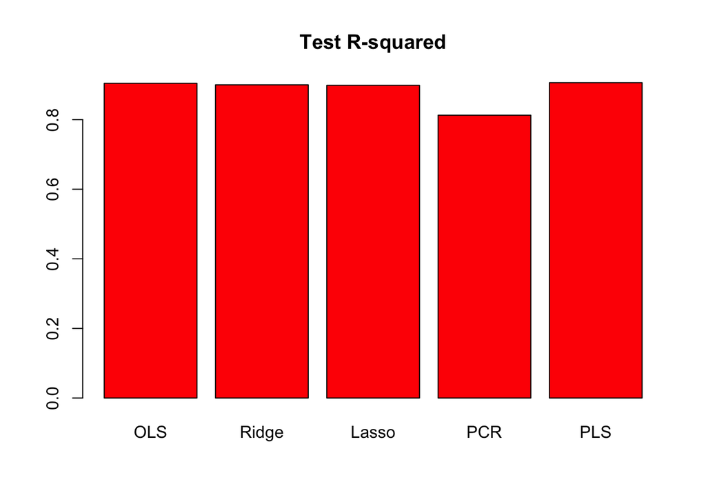

```r
test.avg <- mean(College[test,]$Apps)
tss <- mean( (y.test  - test.avg)^2)
lm.test.r2 <-    1 - mse_lm / tss
ridge.test.r2 <- 1 - mse_ridge_best / tss
lasso.test.r2 <- 1 - mse_lasso_best / tss
pcr.test.r2 <-   1 - mse_pcr /tss
pls.test.r2  <-  1 - mse_pls / tss

barplot(c(lm.test.r2, ridge.test.r2, lasso.test.r2, pcr.test.r2, pls.test.r2)
        ,col=2, names.arg=c("OLS", "Ridge", "Lasso", "PCR", "PLS")
        ,main="Test R-squared")
```

# Ex 10 (Applied )

```r
rm(list=ls())
```

### a)

```r
set.seed(1)
p<-20
n<-1000
X = matrix(rnorm(n*p), n, p)
B = rnorm(p)
#set some values of B to zero
B[3] = 0
B[4] = 0
B[9] = 0
B[19] = 0
B[10] = 0
eps = rnorm(p)

Y <- X%*% B + eps
```

### b)

```r
full_idx <- 1:nrow(X)
train <- sample(full_idx, length(full_idx) * 1/10 ,replace=FALSE)  # train 1/10 th of data
test <- full_idx[-train]
```

### c)

#### training MSE

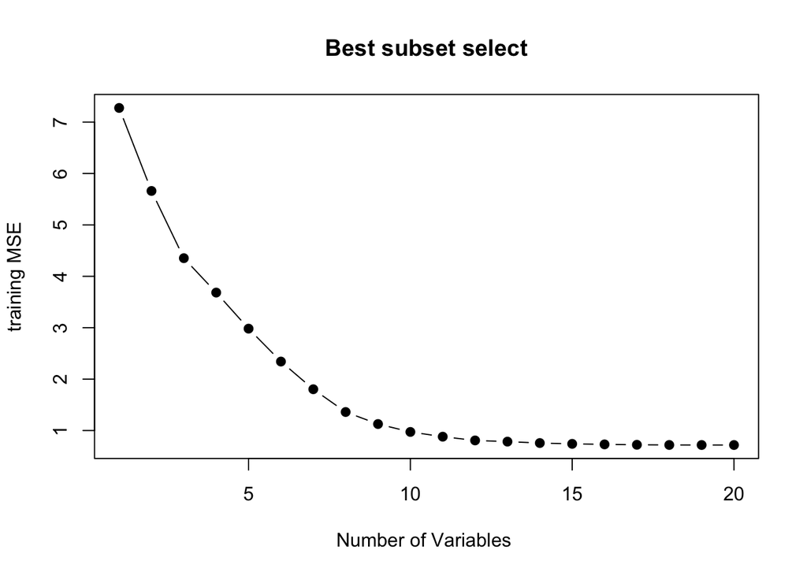

```r
library(leaps)
datas <- data.frame(Y,X)
p_feats <- dim(datas)[2]-1 ## all features
regbsub <- regsubsets(Y~., data=datas[train,], nvmax=p)
regbsum <- summary(regbsub)

plot( regbsum$rss/ length(train),xlab="Number of Variables ",ylab="training MSE",
type="b", pch=19,main="Best subset select")
```

The manual calculation of training MSE

```r
x.train <- datas[train,-1]
y.train <- datas[train,"Y"]
x.test <- datas[test,-1]
y.test <- datas[test,"Y"]

val.errors <- rep(NA,p)

x_cols <- colnames(datas)[-1]
for(i in 1:p){
    coefi <- coef(regbsub, id=i)
    pred <- as.matrix( x.train[,x_cols %in% names(coefi)]) %*% coefi[names(coefi) %in% x_cols ]
    val.errors[i] <- mean((y.train - pred)^2)
}

regbsum$rss/ length(train)
```

```
##  [1] 7.2755259 5.6607357 4.3528379 3.6837368 2.9818134 2.3415708 1.8030194
##  [8] 1.3598510 1.1261887 0.9723440 0.8800271 0.8072361 0.7838201 0.7565316
## [15] 0.7405760 0.7303461 0.7223781 0.7189606 0.7180948 0.7179491
```

```r
val.errors
```

```
##  [1] 7.2989825 5.6704838 4.3673497 3.6848592 2.9917412 2.3500549 1.8030767
##  [8] 1.3598519 1.1261889 0.9730531 0.8854987 0.8142193 0.7917622 0.7652169
## [15] 0.7487414 0.7395876 0.7292843 0.7247847 0.7232147 0.7230146
```

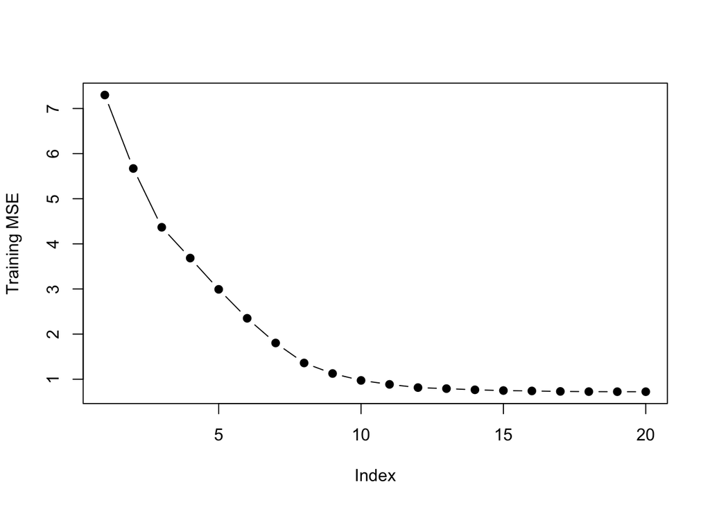

```r
plot(val.errors, ylab="Training MSE", pch=19, type="b")
```

Training MSE decreases monotoniously with a growing complexity of the model.

### d)

#### Test MSE

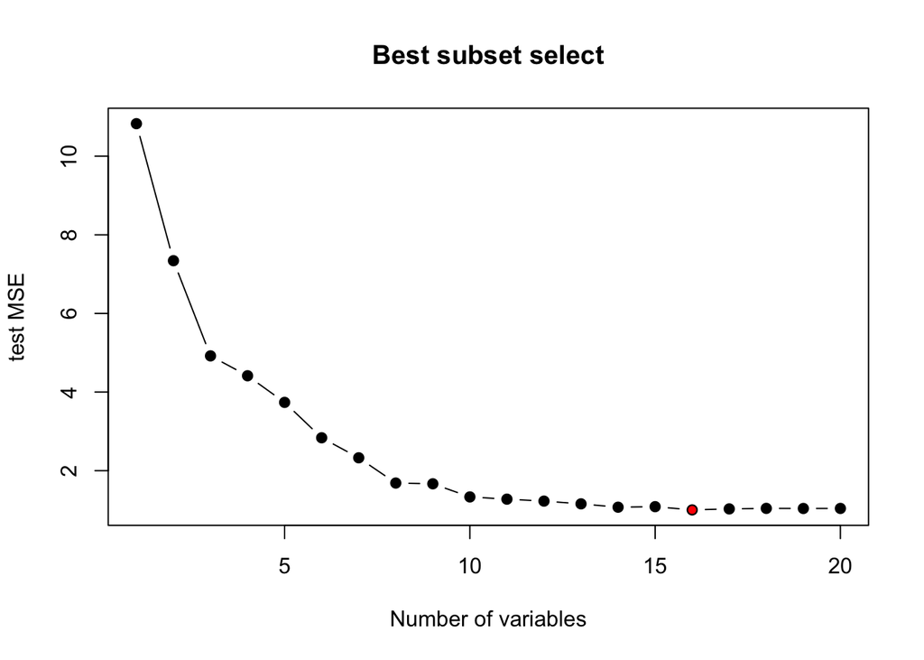

```r
val.t.errors <- rep(NA,p)

for(i in 1:p){
    coefi <- coef(regbsub, id=i)
    pred <- as.matrix( x.test[,x_cols %in% names(coefi)]) %*% coefi[names(coefi) %in% x_cols ]
    val.t.errors[i] <- mean((y.test - pred)^2)
}
plot(val.t.errors,ylab="test MSE", xlab="Number of variables", type="b", pch=19, main="Best subset select")
idx <- which.min(val.t.errors)
points(idx, val.t.errors[idx], col="red", pch=20)
```

### e)

As seen on a previous chart the lowest test MSE is obtained for model with 16 params. We observet that test MSE can increase with a growing complexity of a model.

### f)

##### Compare model coefficients with true betas

```r
print(B)
```

```
##  [1]  0.2353485  0.2448250  0.0000000  0.0000000  1.0386957 -0.2835501
##  [7] -1.4097291  0.7231804  0.0000000  0.0000000  0.8791534  0.5545564
## [13] -0.2845811 -0.6746580 -0.7154889 -0.2705279  0.3129646  1.6698068
## [19]  0.0000000 -1.0154889
```

```r
print( coef(regbsub,id=16) )
```

```
## (Intercept)          X1          X2          X5          X6          X7
##  0.09613244  0.28256751  0.19385802  0.99994674 -0.28597795 -1.50482273
##          X8         X11         X12         X13         X14         X15
##  0.77817125  0.90815918  0.48477881 -0.19747066 -0.71978955 -0.74282068
##         X16         X17         X18         X19         X20
## -0.33900837  0.12234642  1.74270174 -0.12435131 -1.03003019
```

All zero coefficidents are found except X19.

### g)

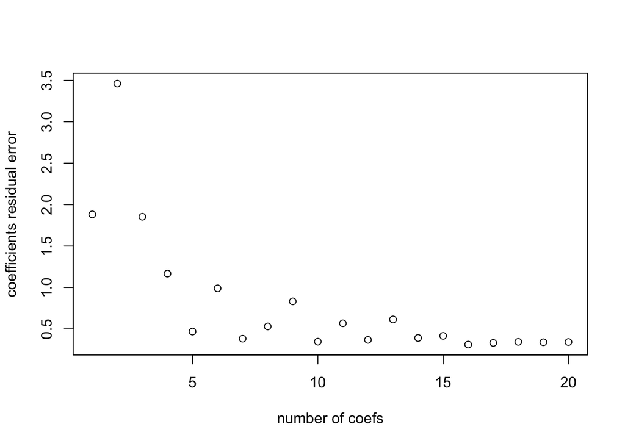

```r
beta.errors <- rep(NA, p)
a <- rep(NA,p)
b <- rep(NA,p)
for (i in 1:p){
    coefi <- coef(regbsub,id=i)
    a[i] <- length(coefi)-1  # number of model params minus intercept
    b[i] <-  sqrt(sum( (B[x_cols %in% names(coefi)] - coefi[ names(coefi) %in% x_cols ] )^2) +
                  sum(B[!(x_cols %in% names(coefi))])^2)
}
plot(x=a, y=b, xlab="number of coefs", ylab="coefficients residual error" )
```

```r
print(which.min(b))
```

```
## [1] 16
```

# Ex 11 (Applied )

```r
rm(list=ls())
set.seed(1)
library(MASS)
library(leaps)
library(glmnet)

data(Boston)
```

### a)

##### Best subset selection model with k-fold validation

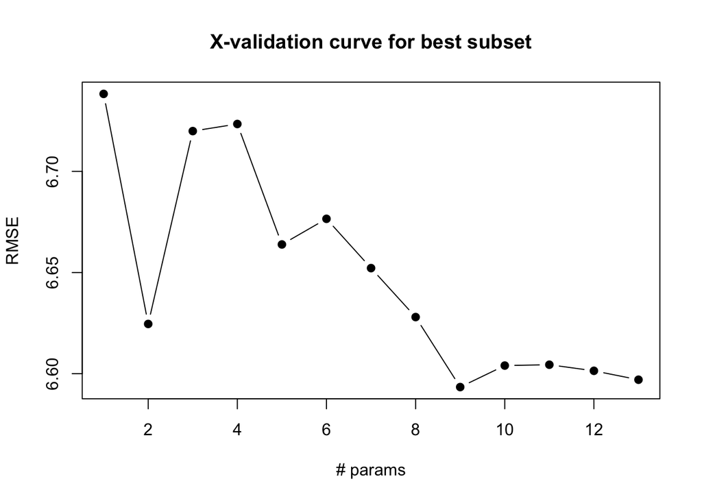

```r
# define predict for bset subset selection function (to compute test mse)
predict.regsubsets = function(object, newdata, id, ...) {
    form = as.formula(object$call[[2]])
    mat = model.matrix(form, newdata)
    coefi = coef(object, id = id)
    mat[, names(coefi)] %*% coefi
}

k<-10  #k-fold validation
p <- ncol(Boston)-1

folds<-sample(rep(1:k, length=nrow(Boston)) )
#print(table(folds))

cv.errors <- matrix(NA,k,p)

#loop on k folds
for (j in 1:k){
    best.fit <- regsubsets(crim~. ,data=Boston[folds!=j,], nvmax =p) #on train
    for (i in 1:p){
        pred <- predict.regsubsets(best.fit, Boston[folds==j,], id=i  ) #predictions of ith model
        cv.errors[j,i] <- mean( (pred - Boston$crim[folds==j] )^2 )
    }
}
rmse.cv <- sqrt(apply(cv.errors, 2, mean))

plot(rmse.cv, type="b", pch=19,main="X-validation curve for best subset", xlab="# params"
     ,ylab="RMSE")
```

```r
min_pars <- which.min(rmse.cv)

bestsub_coefs <- coefficients(best.fit,id=min_pars)
print(bestsub_coefs)
```

```
##   (Intercept)            zn         indus           nox           dis
##  21.056533195   0.045345047  -0.090954491 -11.595481360  -1.087406625
##           rad       ptratio         black         lstat          medv
##   0.547936841  -0.274318819  -0.009357563   0.096806735  -0.191928059
```

```r
rmse.cv.bestsubset <- rmse.cv[min_pars]
print(paste("best subset min rmse:",rmse.cv.bestsubset))
```

```
## [1] "best subset min rmse: 6.59339582778041"
```

#### Lasso

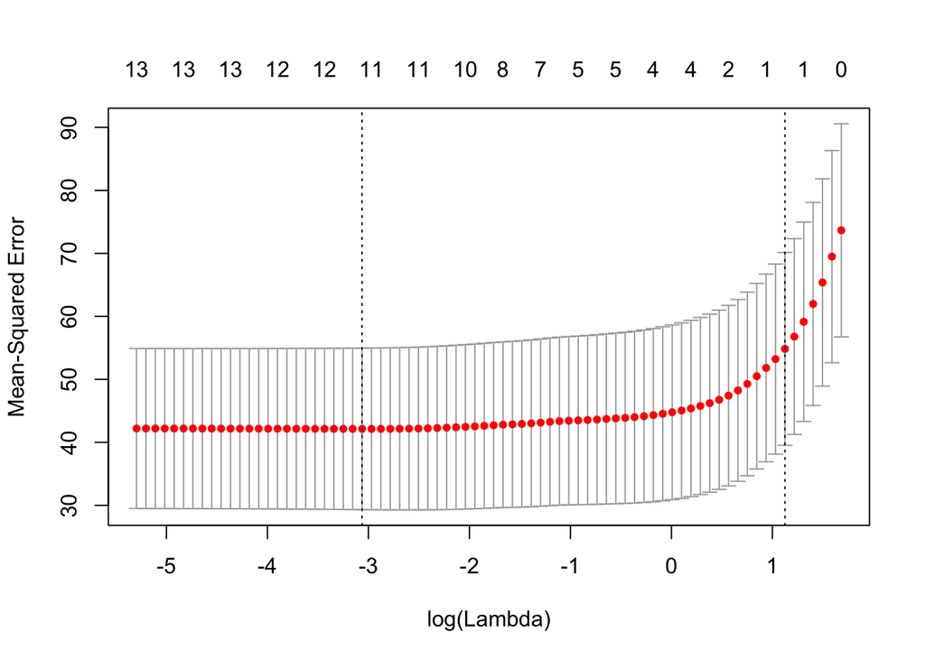

```r
x <- model.matrix(crim~.-1,data=Boston)
y <- Boston$crim
cv.lasso <- cv.glmnet(x,y,type.measure="mse",alpha=1)
plot(cv.lasso)
```

```r
print(coef(cv.lasso))
```

```
## 14 x 1 sparse Matrix of class "dgCMatrix"
##                     1
## (Intercept) 1.0894283
## zn          .
## indus       .
## chas        .
## nox         .
## rm          .
## age         .
## dis         .
## rad         0.2643196
## tax         .
## ptratio     .
## black       .
## lstat       .
## medv        .
```

```r
rmse.cv.lasso <- sqrt(cv.lasso$cvm[cv.lasso$lambda == cv.lasso$lambda.1se])
print(paste("lasso min rmse:",rmse.cv.lasso))
```

```
## [1] "lasso min rmse: 7.40517586584935"
```

#### Ridge

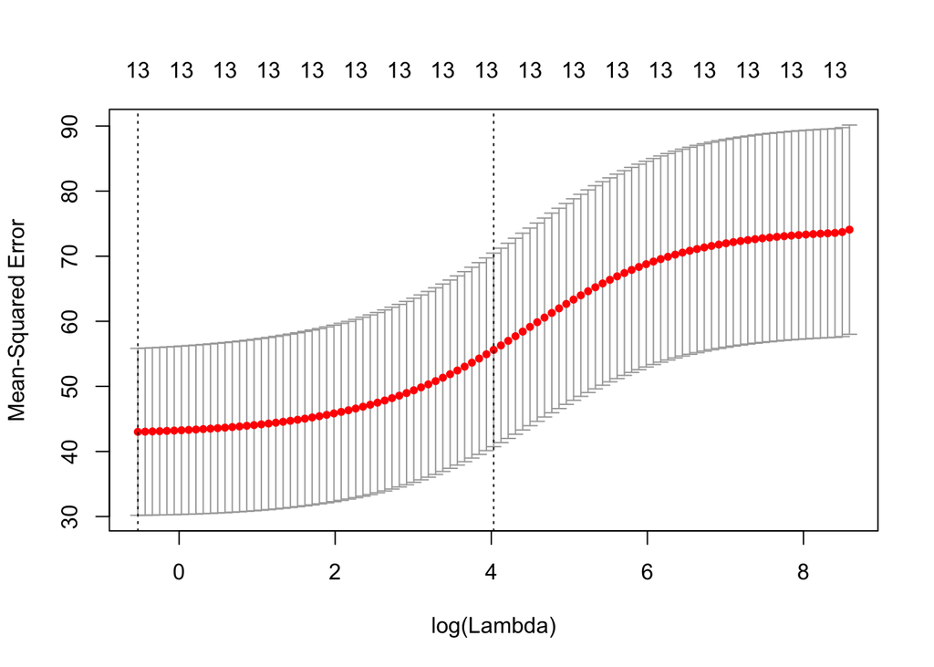

```r
cv.ridge <- cv.glmnet(x,y,type.measure="mse",alpha=0)
plot(cv.ridge)
```

```r
print(coef(cv.ridge))
```

```
## 14 x 1 sparse Matrix of class "dgCMatrix"
##                        1
## (Intercept)  1.017516864
## zn          -0.002805664
## indus        0.034405928
## chas        -0.225250602
## nox          2.249887499
## rm          -0.162546004
## age          0.007343331
## dis         -0.114928730
## rad          0.059813844
## tax          0.002659110
## ptratio      0.086423005
## black       -0.003342067
## lstat        0.044495213
## medv        -0.029124577
```

```r
rmse.cv.ridge <- sqrt(cv.ridge$cvm[ cv.ridge$lambda == cv.ridge$lambda.1se ] )
print(paste("ridge min rmse:",rmse.cv.ridge))
```

```
## [1] "ridge min rmse: 7.45694606217746"
```

#### PCR

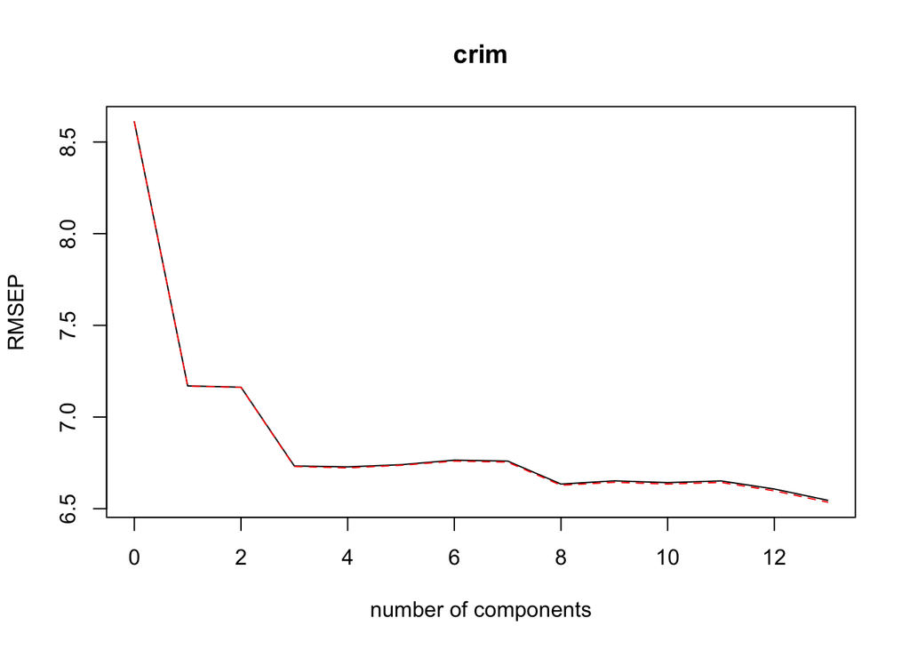

```r
library(pls)
pcr.fit <- pcr(crim~., data=Boston,scale=TRUE, validation="CV")
validationplot(pcr.fit, val.type="RMSEP")
```

```r
print(summary(pcr.fit))
```

```
## Data:    X dimension: 506 13
##  Y dimension: 506 1
## Fit method: svdpc
## Number of components considered: 13
##
## VALIDATION: RMSEP
## Cross-validated using 10 random segments.
##        (Intercept)  1 comps  2 comps  3 comps  4 comps  5 comps  6 comps
## CV            8.61    7.170    7.163    6.733    6.728    6.740    6.765
## adjCV         8.61    7.169    7.162    6.730    6.723    6.737    6.760
##        7 comps  8 comps  9 comps  10 comps  11 comps  12 comps  13 comps
## CV       6.760    6.634    6.652     6.642     6.652     6.607     6.546
## adjCV    6.754    6.628    6.644     6.635     6.643     6.598     6.536
##
## TRAINING: % variance explained
##       1 comps  2 comps  3 comps  4 comps  5 comps  6 comps  7 comps
## X       47.70    60.36    69.67    76.45    82.99    88.00    91.14
## crim    30.69    30.87    39.27    39.61    39.61    39.86    40.14
##       8 comps  9 comps  10 comps  11 comps  12 comps  13 comps
## X       93.45    95.40     97.04     98.46     99.52     100.0
## crim    42.47    42.55     42.78     43.04     44.13      45.4
## NULL
```

#### b)

Compare RMSEs of the model

```r
rmse.cv.bestsubset
```

```
## [1] 6.593396
```

```r
rmse.cv.lasso
```

```
## [1] 7.405176
```

```r
rmse.cv.ridge
```

```
## [1] 7.456946
```

#### c)

Lowest RMSE is from PCR on all 13 predictors. RMSE of best subset model selection with 9 params is close to the onf of PCR but it is a simpler model. Thus it is better to chose the best subset selection model.